```r
options(repos = structure(c(CRAN = "https://cloud.r-project.org/")))
install.packages("ggplot2")
install.packages("ggplot2", dependencies=TRUE)
library(data.table)

# Load the data
vehicles <- fread("vehicles.csv")

# View the first few rows
head(vehicles)
```

```
##            id
## 1: 7222695916
## 2: 7218891961
## 3: 7221797935
## 4: 7222270760
## 5: 7210384030
## 6: 7222379453
##                                                                                             url
## 1:              https://prescott.craigslist.org/cto/d/prescott-2010-ford-ranger/7222695916.html
## 2:       https://fayar.craigslist.org/ctd/d/bentonville-2017-hyundai-elantra-se/7218891961.html
## 3:              https://keys.craigslist.org/cto/d/summerland-key-2005-excursion/7221797935.html
## 4: https://worcester.craigslist.org/cto/d/west-brookfield-2002-honda-odyssey-ex/7222270760.html
## 5:         https://greensboro.craigslist.org/cto/d/trinity-1965-chevrolet-truck/7210384030.html
## 6:             https://hudsonvalley.craigslist.org/cto/d/westtown-2007-ford-150/7222379453.html
##                    region                          region_url price year
```

[output cut: 27 more lines]

```r
col_missing <- sapply(vehicles, function(col) sum(is.na(col)))
```

```r
median_odometer <- median(vehicles$odometer, na.rm = TRUE)
vehicles$odometer[is.na(vehicles$odometer)] <- median_odometer

# Drop rows with missing lat or long values
vehicles <- vehicles[!is.na(vehicles$lat) & !is.na(vehicles$long),]


vehicles <- vehicles[!is.na(vehicles$posting_date),]
# Example: Drop the county column
vehicles$county <- NULL
```

```r
# For a continuous variable like 'odometer'
vehicles$odometer[is.na(vehicles$odometer)] <- mean(vehicles$odometer, na.rm = TRUE)

# For a categorical variable like 'fuel'
mode_fuel <- as.character(names(sort(table(vehicles$fuel), decreasing=TRUE)[1]))
vehicles$fuel[is.na(vehicles$fuel)] <- mode_fuel
```

```r
# Check for missing values in each column
sapply(vehicles, function(col) sum(is.na(col)))
```

```
##           id          url       region   region_url        price         year
##            0            0            0            0            0            0
## manufacturer        model    condition    cylinders         fuel     odometer
##            0            0            0            0            0            0
## title_status transmission          VIN        drive         size         type
##            0            0            0            0            0            0
##  paint_color    image_url  description        state          lat         long
##            0            0            0            0            0            0
## posting_date
##            0
```

```r
vehicles <- vehicles[!duplicated(vehicles), ]

str(vehicles)# function to check the structure and types of dataset's columns.
```

```
## Classes 'data.table' and 'data.frame':   420331 obs. of  25 variables:
##  $ id          : chr  "7316814884" "7316814758" "7316814989" "7316743432" ...
##  $ url         : chr  "https://auburn.craigslist.org/ctd/d/auburn-university-2014-gmc-sierra-1500/7316814884.html" "https://auburn.craigslist.org/ctd/d/auburn-university-2010-chevy-chevrolet/7316814758.html" "https://auburn.craigslist.org/ctd/d/auburn-university-2020-chevy-chevrolet/7316814989.ht…
##  $ region      : chr  "auburn" "auburn" "auburn" "auburn" ...
##  $ region_url  : chr  "https://auburn.craigslist.org" "https://auburn.craigslist.org" "https://auburn.craigslist.org" "https://auburn.craigslist.org" ...
##  $ price       : chr  "33590" "22590" "39590" "30990" ...
##  $ year        : chr  "2014" "2010" "2020" "2017" ...
##  $ manufacturer: chr  "gmc" "chevrolet" "chevrolet" "toyota" ...
##  $ model       : chr  "sierra 1500 crew cab slt" "silverado 1500" "silverado 1500 crew" "tundra double cab sr" ...
##  $ condition   : chr  "good" "good" "good" "good" ...
##  $ cylinders   : chr  "8 cylinders" "8 cylinders" "8 cylinders" "8 cylinders" ...
##  $ fuel        : chr  "gas" "gas" "gas" "gas" ...
##  $ odometer    : num  57923 71229 19160 41124 128000 ...
##  $ title_status: chr  "clean" "clean" "clean" "clean" ...
##  $ transmission: chr  "other" "other" "other" "other" ...
##  $ VIN         : chr  "3GTP1VEC4EG551563" "1GCSCSE06AZ123805" "3GCPWCED5LG130317" "5TFRM5F17HX120972" ...
##  $ drive       : chr  "" "" "" "" ...
##  $ size        : chr  "" "" "" "" ...
##  $ type        : chr  "pickup" "pickup" "pickup" "pickup" ...
##  $ paint_color : chr  "white" "blue" "red" "red" ...
##  $ image_url   : chr  "https://images.craigslist.org/00R0R_lwWjXSEWNa7z_0x20oM_600x450.jpg" "https://images.craigslist.org/00R0R_lwWjXSEWNa7z_0x20oM_600x450.jpg" "https://images.craigslist.org/01212_jjirIWa0y02z_0gw0co_600x450.jpg" "https://images.craigslist.org/00x0x_1y9kIOzGCFaz_0gw0co_600x450.…
##  $ description : chr  "Carvana is the safer way to buy a car During these uncertain times, Carvana is dedicated to ensuring safety for"| __truncated__ "Carvana is the safer way to buy a car During these uncertain times, Carvana is dedicated to ensuring safety for"| __truncated__ "Carvana is the s…
##  $ state       : chr  "al" "al" "al" "al" ...
##  $ lat         : num  32.6 32.6 32.6 32.6 32.6 ...
##  $ long        : num  -85.5 -85.5 -85.5 -85.5 -85.5 ...
##  $ posting_date: POSIXct, format: "2021-05-04 17:31:18" "2021-05-04 17:31:08" ...
##  - attr(*, ".internal.selfref")=<externalptr>
```

```r
library(data.table)

# Convert to numeric
vehicles[, price := as.numeric(price)]
vehicles[, year := as.numeric(year)]

# Ensure no errors occurred during conversion
vehicles[!is.finite(price), price := NA]
vehicles[!is.finite(year), year := NA]
```

```r
vehicles[drive == "", drive := NA]
vehicles[size == "", size := NA]
```

```r
# Treat vehicles with a price of 0 as missing values
vehicles[price == 0, price := NA]

# Treat extremely high prices (e.g., above 1 million) as missing values
vehicles[price > 1e6, price := NA]
```

```r
summary(vehicles$price)
```

```
##    Min. 1st Qu.  Median    Mean 3rd Qu.    Max.    NA's
##       1    7000   15000   18912   27590 1000000   29888
```

#Minimum: The minimum price is now 1. While this is still very low for a vehicle, it is more plausible than a price of zero. #1st Quartile: The first quartile (25th percentile) price is 7,000, suggesting that 25% of the vehicles are priced at 7,000 or less. #Median: The median price (50th percentile) is 15,000, meaning half of the vehicles are priced below this and half are priced above. #Mean: The average price of the vehicles is 18,912. #3rd Quartile: The third quartile (75th percentile) price is 27,590, meaning 75% of vehicles are priced below this value. #Maximum: The maximum price is 1,000,000, which, although high, is plausible for certain luxury or collector’s vehicles. #NA’s: There are 29,888 vehicles with missing price values (either originally missing or set to NA during our cleaning).

```r
# Convert all character columns to lowercase
char_cols <- names(vehicles)[sapply(vehicles, is.character)]
vehicles[, (char_cols) := lapply(.SD, tolower), .SDcols = char_cols]
```

##Data Exploration and Visualization: Descriptive Statistics: Generate summary statistics for numerical and categorical columns. Visualizations: Plot histograms, bar plots, scatter plots, and box plots to understand the distribution and relationships in the data.

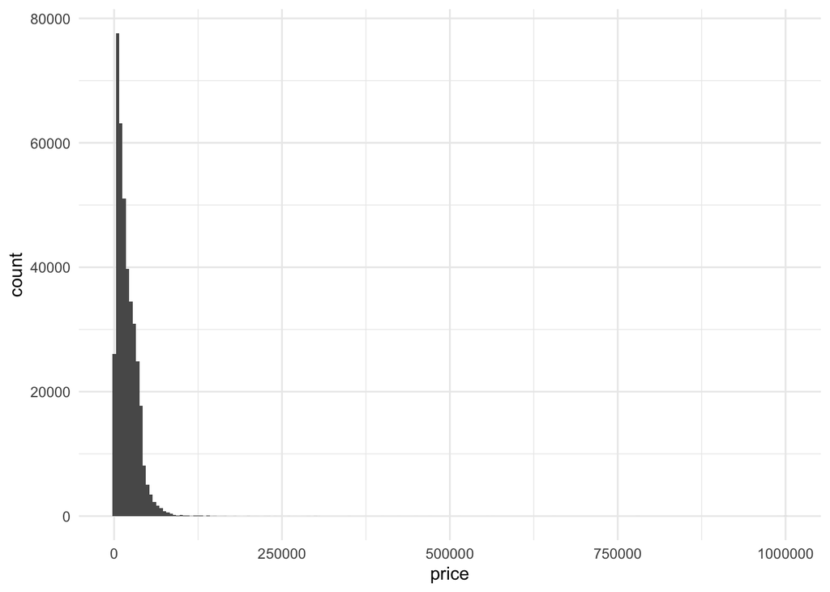

```r
install.packages("ggplot2")
library(ggplot2)
# Histogram for price
ggplot(vehicles, aes(price)) + geom_histogram(binwidth=5000) + theme_minimal()
```

```r
# Convert 'year' column to numeric
vehicles$year <- as.numeric(vehicles$year)

# Calculate the current year
current_year <- as.numeric(format(Sys.Date(), "%Y"))

# Compute the number of years the car has been used for
vehicles$age_of_car <- current_year - vehicles$year
```

```r
# Write a new dataset after dropping the irrelevant variables
new_vehicles <- vehicles
new_vehicles$image_url <- NULL
new_vehicles$description <- NULL
new_vehicles$VIN <- NULL
new_vehicles$year <- NULL
new_vehicles$url <- NULL
new_vehicles$region_url <- NULL
```

```r
#New dataset derived from the vehicles dataset
write.csv(new_vehicles, file = "new_vehicles.csv", row.names = FALSE)

summary(new_vehicles)
```

```
##       id               region              price         manufacturer
##  Length:420331      Length:420331      Min.   :      1   Length:420331
##  Class :character   Class :character   1st Qu.:   7000   Class :character
##  Mode  :character   Mode  :character   Median :  15000   Mode  :character
##                                        Mean   :  18912
##                                        3rd Qu.:  27590
##                                        Max.   :1000000
##                                        NA's   :29888
##     model            condition          cylinders             fuel
##  Length:420331      Length:420331      Length:420331      Length:420331
##  Class :character   Class :character   Class :character   Class :character
##  Mode  :character   Mode  :character   Mode  :character   Mode  :character
##
##
##
##
##     odometer        title_status       transmission          drive
##  Min.   :       0   Length:420331      Length:420331      Length:420331
##  1st Qu.:   38112   Class :character   Class :character   Class :character
##  Median :   85548   Mode  :character   Mode  :character   Mode  :character
##  Mean   :   98213
##  3rd Qu.:  133409
##  Max.   :10000000
##
##      size               type           paint_color           state
##  Length:420331      Length:420331      Length:420331      Length:420331
##  Class :character   Class :character   Class :character   Class :character
##  Mode  :character   Mode  :character   Mode  :character   Mode  :character
##
##
##
##
##       lat              long          posting_date
##  Min.   :-84.12   Min.   :-159.83   Min.   :2021-04-04 07:00:25.00
##  1st Qu.: 34.60   1st Qu.:-111.94   1st Qu.:2021-04-17 10:23:59.50
##  Median : 39.15   Median : -88.43   Median :2021-04-26 05:01:41.00
##  Mean   : 38.49   Mean   : -94.75   Mean   :2021-04-24 00:47:58.78
##  3rd Qu.: 42.40   3rd Qu.: -80.83   3rd Qu.:2021-05-01 13:42:10.00
##  Max.   : 82.39   Max.   : 173.89   Max.   :2021-05-05 04:24:09.00
##
##    age_of_car
##  Min.   :  1.00
##  1st Qu.:  6.00
##  Median : 10.00
##  Mean   : 11.81
##  3rd Qu.: 15.00
##  Max.   :123.00
##  NA's   :1137
```

## Data Dictionary

#This section provides a descriptive breakdown of the variables in the dataset:

[output not shown]

## Data Cleaning & Preprocessing

Upon importing the dataset, the following preprocessing steps were taken:

1. **Duplicates**: Duplicates were identified and removed to ensure that each listing in the dataset is unique.
2. **Age of Car**: We transformed the ‘year’ column to reflect the age of the vehicle. This was done by subtracting the year of manufacture from the current year. The original ‘year’ column was then dropped as it became redundant.
3. **Dropping Columns**: Certain columns like ‘url’, ‘image_url’, ‘description’, ‘VIN’, and ‘region_url’ were removed. This decision was based on the assumption that these columns would not provide significant insight into our analysis.

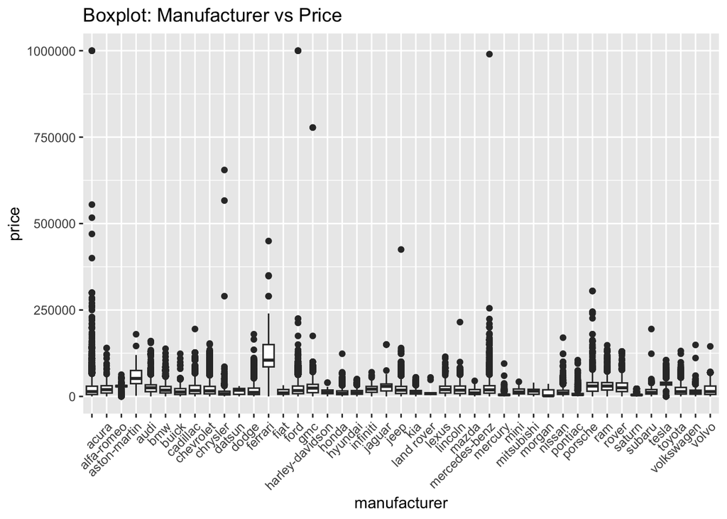

```r
install.packages("ggplot2")
library(ggplot2)
ggplot(vehicles, aes(x=manufacturer, y=price)) +
  geom_boxplot() +
  labs(title="Boxplot: Manufacturer vs Price") +
  theme(axis.text.x=element_text(angle=45, hjust=1))
```

[figure not shown]

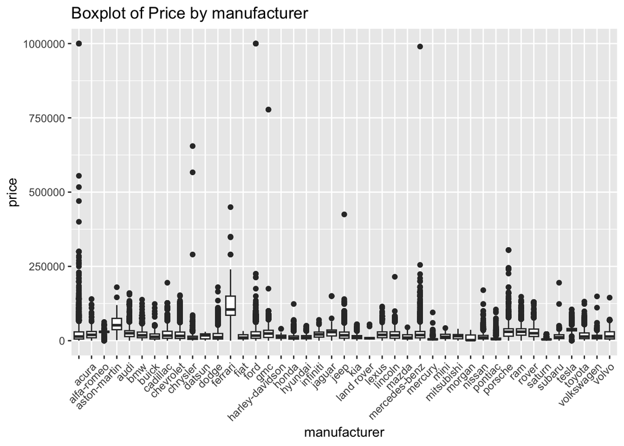

[figure not shown]

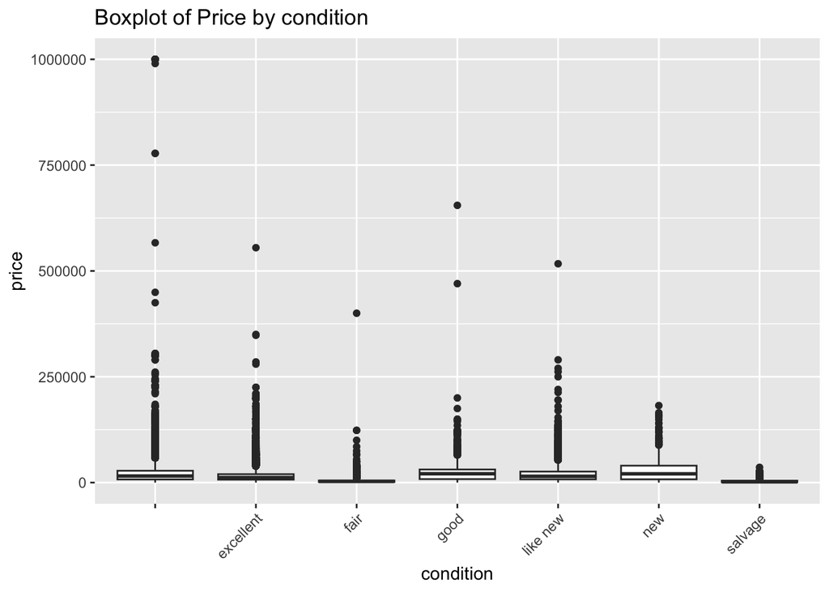

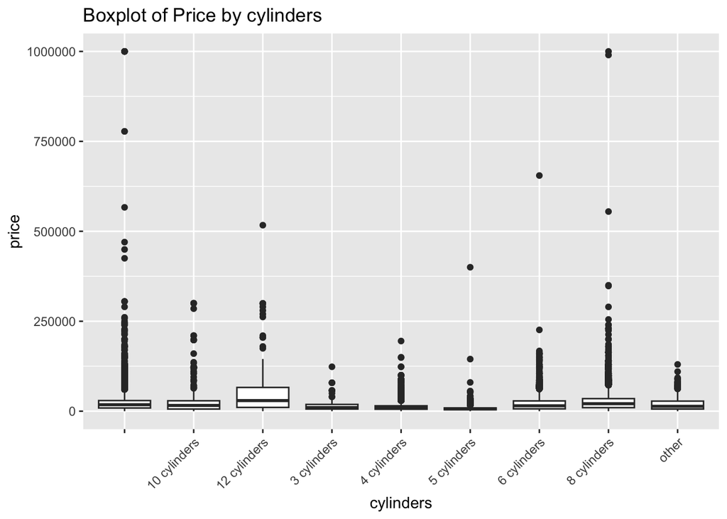

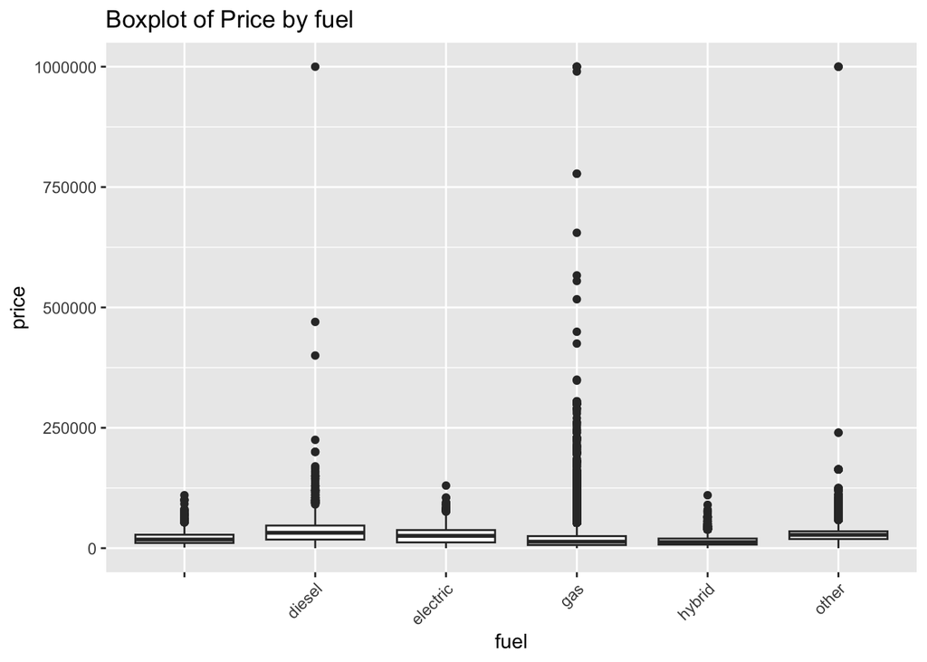

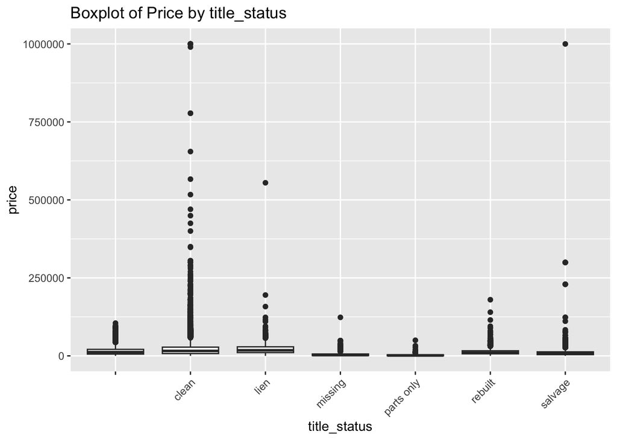

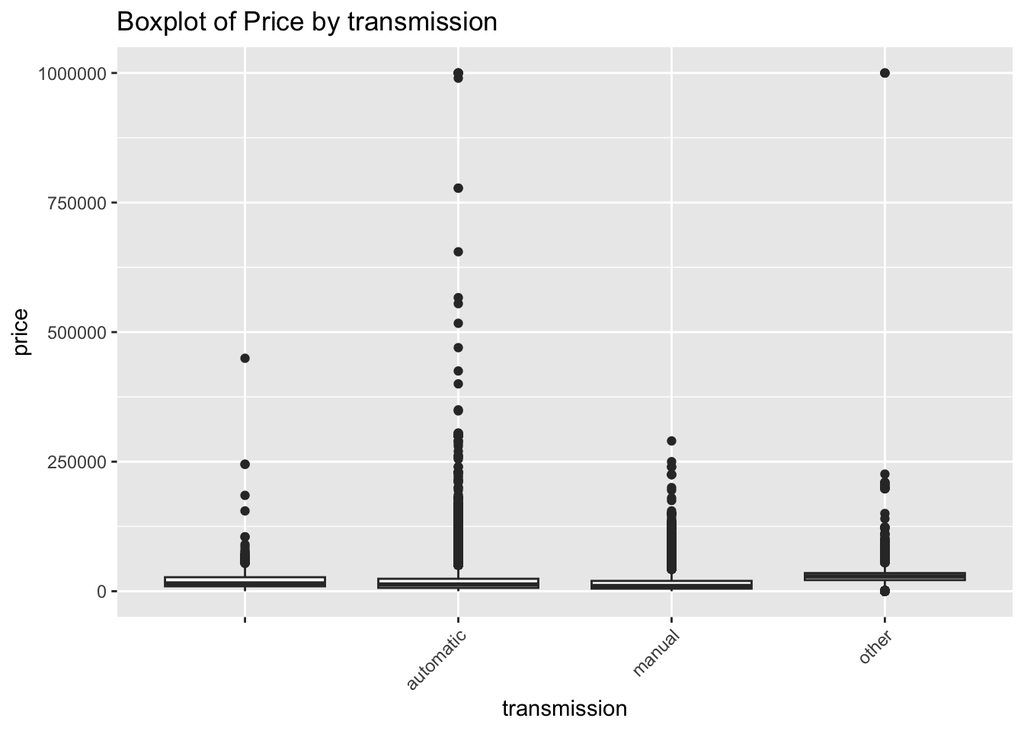

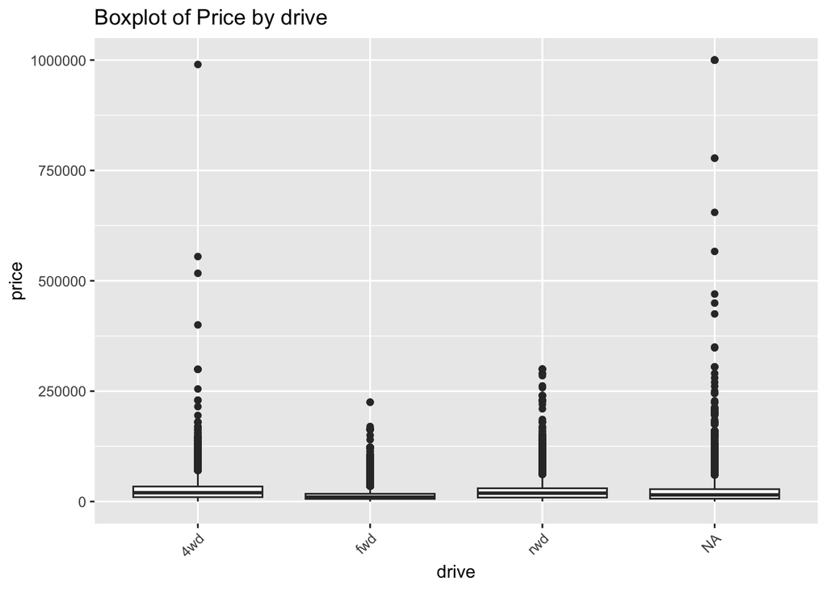

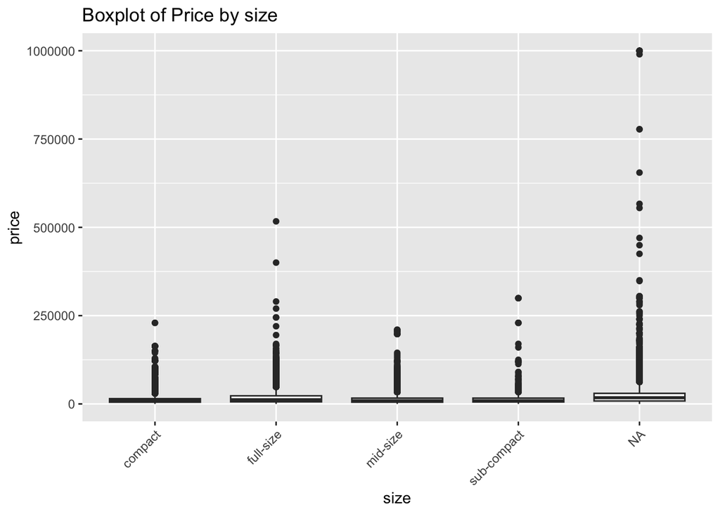

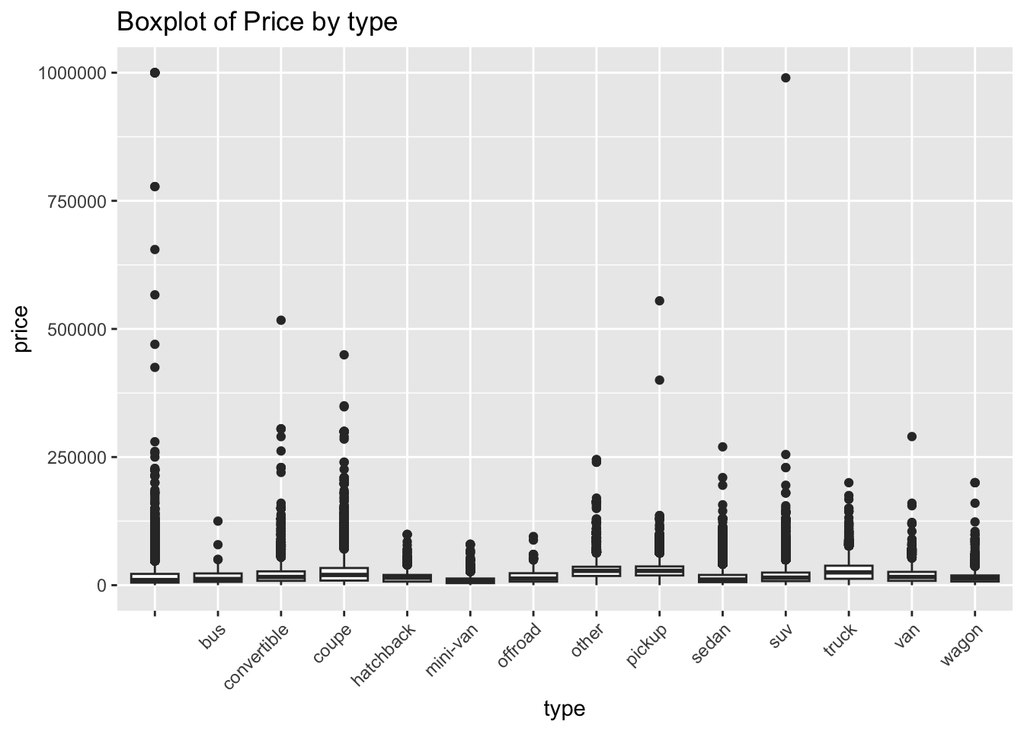

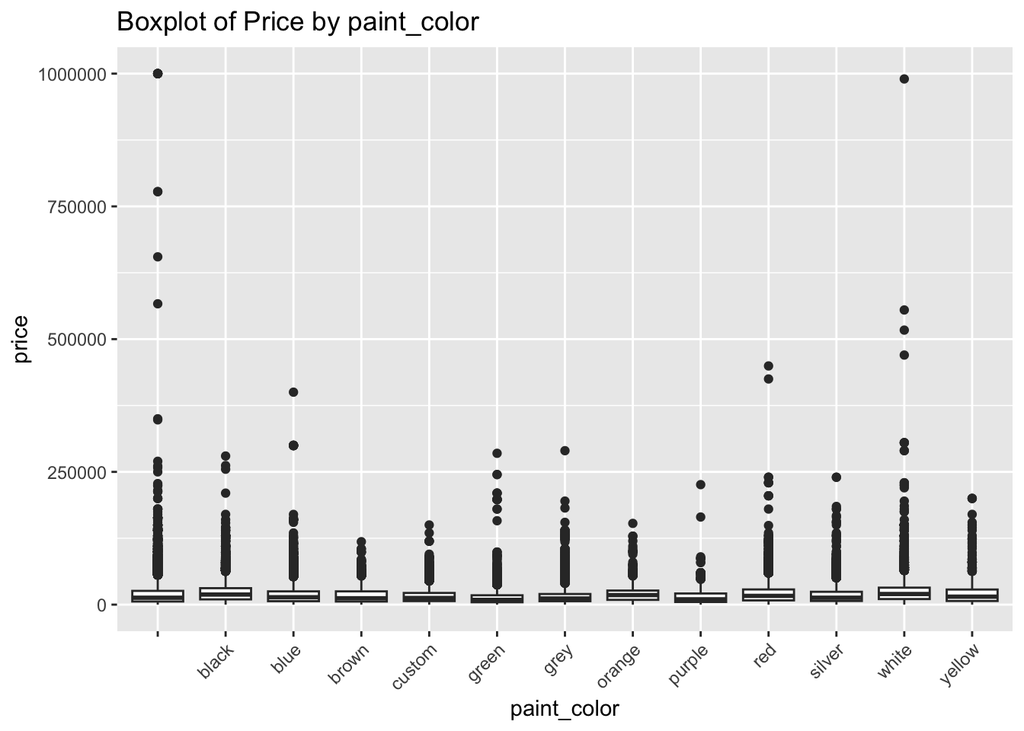

[1 more figures not shown]

```r
# Load ggplot2
library(ggplot2)

# Select categorical variables
categorical_vars <- c("region", "manufacturer", "model", "condition", "cylinders",
                      "fuel", "title_status", "transmission", "drive", "size",
                      "type", "paint_color", "state")

# Loop through each variable and create a boxplot
for (cat_var in categorical_vars) {
  plot <- ggplot(vehicles, aes_string(x = cat_var, y = "price")) +
          geom_boxplot() +
          labs(title = paste("Boxplot of Price by", cat_var)) +
          theme(axis.text.x = element_text(angle = 45, hjust = 1))
  print(plot)
}
```

```r
summary(vehicles)
```

```
##       id                url               region           region_url
##  Length:420331      Length:420331      Length:420331      Length:420331
##  Class :character   Class :character   Class :character   Class :character
##  Mode  :character   Mode  :character   Mode  :character   Mode  :character
##
##
##
##
##      price              year      manufacturer          model
##  Min.   :      1   Min.   :1900   Length:420331      Length:420331
##  1st Qu.:   7000   1st Qu.:2008   Class :character   Class :character
##  Median :  15000   Median :2013   Mode  :character   Mode  :character
##  Mean   :  18912   Mean   :2011
##  3rd Qu.:  27590   3rd Qu.:2017
##  Max.   :1000000   Max.   :2022
##  NA's   :29888     NA's   :1137
##   condition          cylinders             fuel              odometer
##  Length:420331      Length:420331      Length:420331      Min.   :       0
##  Class :character   Class :character   Class :character   1st Qu.:   38112
##  Mode  :character   Mode  :character   Mode  :character   Median :   85548
##                                                           Mean   :   98213
##                                                           3rd Qu.:  133409
##                                                           Max.   :10000000
##
##  title_status       transmission           VIN               drive
##  Length:420331      Length:420331      Length:420331      Length:420331
##  Class :character   Class :character   Class :character   Class :character
##  Mode  :character   Mode  :character   Mode  :character   Mode  :character
##
##
##
##
##      size               type           paint_color         image_url
##  Length:420331      Length:420331      Length:420331      Length:420331
##  Class :character   Class :character   Class :character   Class :character
##  Mode  :character   Mode  :character   Mode  :character   Mode  :character
##
##
##
##
##  description           state                lat              long
##  Length:420331      Length:420331      Min.   :-84.12   Min.   :-159.83
##  Class :character   Class :character   1st Qu.: 34.60   1st Qu.:-111.94
##  Mode  :character   Mode  :character   Median : 39.15   Median : -88.43
##                                        Mean   : 38.49   Mean   : -94.75
##                                        3rd Qu.: 42.40   3rd Qu.: -80.83
##                                        Max.   : 82.39   Max.   : 173.89
##
##   posting_date                      age_of_car
##  Min.   :2021-04-04 07:00:25.00   Min.   :  1.00
##  1st Qu.:2021-04-17 10:23:59.50   1st Qu.:  6.00
##  Median :2021-04-26 05:01:41.00   Median : 10.00
##  Mean   :2021-04-24 00:47:58.78   Mean   : 11.81
##  3rd Qu.:2021-05-01 13:42:10.00   3rd Qu.: 15.00
##  Max.   :2021-05-05 04:24:09.00   Max.   :123.00
##                                   NA's   :1137
```

```r
for (col in names(vehicles)) {
  if (is.numeric(vehicles[[col]])) {
    print(paste("Summary for", col))
    print(summary(vehicles[[col]]))
  } else if (is.factor(vehicles[[col]])) {
    print(paste("Table for", col))
    print(table(vehicles[[col]]))
  }
}
```

```
## [1] "Summary for price"
##    Min. 1st Qu.  Median    Mean 3rd Qu.    Max.    NA's
##       1    7000   15000   18912   27590 1000000   29888
## [1] "Summary for year"
##    Min. 1st Qu.  Median    Mean 3rd Qu.    Max.    NA's
##    1900    2008    2013    2011    2017    2022    1137
## [1] "Summary for odometer"
##     Min.  1st Qu.   Median     Mean  3rd Qu.     Max.
##        0    38112    85548    98213   133409 10000000
## [1] "Summary for lat"
##    Min. 1st Qu.  Median    Mean 3rd Qu.    Max.
##  -84.12   34.60   39.15   38.49   42.40   82.39
## [1] "Summary for long"
##    Min. 1st Qu.  Median    Mean 3rd Qu.    Max.
## -159.83 -111.94  -88.43  -94.75  -80.83  173.89
## [1] "Summary for age_of_car"
##    Min. 1st Qu.  Median    Mean 3rd Qu.    Max.    NA's
##    1.00    6.00   10.00   11.81   15.00  123.00    1137
```

```r
# Running a simple multiple regression model with a few predictors as an example
model <- lm(price ~ manufacturer + age_of_car + odometer + transmission, data=vehicles)

# Get summary statistics of the model
summary(model)
```

```
##
## Call:
## lm(formula = price ~ manufacturer + age_of_car + odometer + transmission,
##     data = vehicles)
##
## Residuals:
##     Min      1Q  Median      3Q     Max
## -127883   -7812   -2288    5106  982567
##
## Coefficients:
##                               Estimate Std. Error  t value Pr(>|t|)
## (Intercept)                  3.014e+04  3.614e+02   83.398  < 2e-16 ***
## manufactureracura           -5.168e+03  2.237e+02  -23.103  < 2e-16 ***
## manufactureralfa-romeo      -1.712e+03  5.067e+02   -3.378 0.000730 ***
## manufactureraston-martin     3.907e+04  3.110e+03   12.562  < 2e-16 ***
## manufactureraudi            -8.007e+02  2.071e+02   -3.866 0.000111 ***
## manufacturerbmw             -3.609e+03  1.716e+02  -21.035  < 2e-16 ***
## manufacturerbuick           -7.926e+03  2.307e+02  -34.353  < 2e-16 ***
## manufacturercadillac        -3.086e+03  2.122e+02  -14.541  < 2e-16 ***
## manufacturerchevrolet       -1.673e+03  1.338e+02  -12.500  < 2e-16 ***
## manufacturerchrysler        -1.078e+04  2.236e+02  -48.202  < 2e-16 ***
## manufacturerdatsun           7.378e+03  1.800e+03    4.099 4.15e-05 ***
## manufacturerdodge           -6.667e+03  1.745e+02  -38.195  < 2e-16 ***
## manufacturerferrari          1.053e+05  1.587e+03   66.332  < 2e-16 ***
## manufacturerfiat            -1.435e+04  5.268e+02  -27.232  < 2e-16 ***
## manufacturerford            -6.077e+02  1.308e+02   -4.648 3.36e-06 ***
## manufacturergmc              2.156e+03  1.652e+02   13.050  < 2e-16 ***
## manufacturerharley-davidson -8.054e+03  1.223e+03   -6.586 4.53e-11 ***
## manufacturerhonda           -1.052e+04  1.556e+02  -67.611  < 2e-16 ***
## manufacturerhyundai         -1.212e+04  1.898e+02  -63.841  < 2e-16 ***
## manufacturerinfiniti        -4.491e+03  2.446e+02  -18.363  < 2e-16 ***
## manufacturerjaguar           9.108e+02  3.483e+02    2.615 0.008935 **
## manufacturerjeep            -3.472e+03  1.601e+02  -21.689  < 2e-16 ***
## manufacturerkia             -1.226e+04  2.037e+02  -60.217  < 2e-16 ***
## manufacturerland rover      -3.072e+03  4.295e+03   -0.715 0.474460
## manufacturerlexus           -3.314e+03  2.026e+02  -16.356  < 2e-16 ***
## manufacturerlincoln         -3.676e+03  2.548e+02  -14.425  < 2e-16 ***
## manufacturermazda           -1.086e+04  2.330e+02  -46.608  < 2e-16 ***
## manufacturermercedes-benz    8.476e+00  1.848e+02    0.046 0.963411
## manufacturermercury         -9.918e+03  4.396e+02  -22.562  < 2e-16 ***
```

[output cut: 11 more lines]

```
## manufacturertoyota          -5.430e+03  1.429e+02  -37.988  < 2e-16 ***
## manufacturervolkswagen      -1.066e+04  1.918e+02  -55.609  < 2e-16 ***
## manufacturervolvo           -4.936e+03  2.756e+02  -17.912  < 2e-16 ***
## age_of_car                  -4.720e+02  2.628e+00 -179.563  < 2e-16 ***
## odometer                    -7.393e-03  1.134e-04  -65.189  < 2e-16 ***
## transmissionautomatic       -2.564e+03  3.406e+02   -7.527 5.20e-14 ***
## transmissionmanual           1.061e+03  3.537e+02    2.998 0.002716 **
## transmissionother            5.273e+03  3.450e+02   15.284  < 2e-16 ***
## ---
## Signif. codes:  0 '***' 0.001 '**' 0.01 '*' 0.05 '.' 0.1 ' ' 1
##
## Residual standard error: 14240 on 389284 degrees of freedom
##   (30999 observations deleted due to missingness)
## Multiple R-squared:  0.2335, Adjusted R-squared:  0.2335
## F-statistic:  2524 on 47 and 389284 DF,  p-value: < 2.2e-16
```

Summary: The regression model attempts to predict the price of a vehicle based on its manufacturer, age of the car, odometer reading, and transmission type.

Residuals: These values tell you about the distribution of the residuals (predicted - observed values). A more uniform distribution of residuals around zero would be ideal. In this case, there are some large positive and negative residuals, suggesting that there might be some outliers or extreme values affecting the model.

Coefficients: Intercept: The estimated price (in dollars) when all predictors are zero (or at their reference levels). The intercept is $30,140. manufacturer: Each coefficient here indicates the difference in the estimated price of a vehicle from the reference category (which is not listed in the output). For instance, vehicles by manufacturer acura are, on average, $5,168 less expensive than the reference category when all other variables are held constant. age_of_car: With every year increase in the age of a car, its price decreases by $472. This is consistent with the general understanding that older cars tend to be cheaper. odometer: For every additional mile on the odometer, the price decreases by $0.00739. This implies that cars with higher mileage are priced lower. transmission: Compared to the reference transmission category, automatic transmission cars are on average $2,564 cheaper, manual transmission cars are $1,061 more expensive, and other types of transmissions are $5,273 more expensive. Significance Codes: The asterisks next to the coefficients represent the significance levels:

Model Fit: Residual Standard Error: This is the average amount that the response will deviate from the true regression line. In this case, it’s $14,240. Multiple R-squared: This value (0.2335) tells us that approximately 23.35% of the variability in the price is explained by the model. It’s a measure of how well the model fits the data. In general, a higher R-squared indicates a better fit. Adjusted R-squared: It adjusts the R-squared for the number of predictors in the model. In this case, it’s almost identical to R-squared, which means adding predictors hasn’t overly complicated the model. F-statistic & p-value: The F-statistic tests the hypothesis that the model with no predictors fits the data as well as your model. A low p-value (< 2.2e-16) indicates that your model fits the data better than the intercept-only model. Notes: The age_of_car and odometer variables are highly significant, suggesting they are important predictors of price. Most manufacturers are significant predictors of price as well, with some (like ferrari) having a much larger positive effect than others. The dataset has some missing values since 30,999 observations were deleted due to missingness. Considerations: The R-squared suggests that while the model captures some of the variability, a large portion (around 76.65%) remains unexplained. Additional variables or more advanced modeling techniques might help improve this. The large residuals in the summary suggest that there are potentially some outliers or influential points that might be unduly affecting the model’s fit. It could be useful to investigate these further. It’s essential to validate this model on a separate test set to assess its predictive performance.